# 20220330_lisbon_impact_on_bank_products

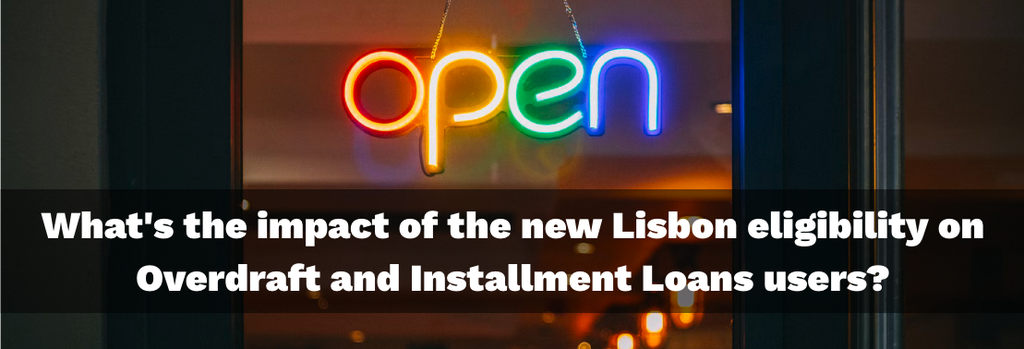

### Intro

Lisbon is a Data Science microservice that calculates Probability of Default (PD) at N26. In the beginning of April 2022, we went live with version 2.0 of this service, which came with a major change to Lisbon Codebase - you can find more information on this change [here](https://number26-jira.atlassian.net/wiki/spaces/DATA/pages/2647818474/LS+2.0+Release+Notes) .

These changes mean that the way we calculate the probability of default are now different after this release, leading to users that weren't eligible in the past for Overdraft and Transaction Based Installment Loans (also mentioned as TBIL or Installment Loans) are now eligible, and vice-versa. Therefore, this deep-dive aims to evaluate these eligibility changes by comparing users eligible at the end of February 2022 (with the old version of Lisbon), and end of March 2022 (taking all eligibility parameters as of this date, and new Lisbon scores as of April 4th).

The eligibility criteria used in this research were:

#### Overdraft Eligibility Criteria

Tracked:

- their calculated internal credit score is 12 or below
- the accepted T&C country is Germany or Austria
- age is not less than 18
- don't have a seized account
- customer doesn't have 2 or more direct debit reversal, due to insufficient funds, within the last 3 months
- no ongoing dunning process for this customer

Not Tracked:

- customer is not receiving unemployment or similar social benefit
- customer is not receiving substitute payments in case of bankrupt employers

#### Installment Loans Eligibility Criteria

Tracked:

- has an eligible Lisbon score (in Einsteinium), up to 12 in DEU, ESP and ITA, up to 9 in FRA
- has German T&Cs (adding specific details for other markets)
- doesn't have an on-going dunning process
- haven't had an installment loan written-off

### Below we will be answering the following questions:

- How many users are eligible before and after the Lisbon upgrade?
- How did the changes impact users' eligibility?
- How many no longer eligible users are using our products?
- What is the credit score distribution of the users who are no longer eligible?

### Our main insights are:

# How many users are eligible before and after the Lisbon upgrade?

Here we can see that for both Overdraft and Installment Loans users we see an increase of the number of eligible users between February and March. Also, we can see that the German market consistently has more eligible users than all other markets combined.

[interactive chart not shown]

Most of our product KPIs are based on the number of eligible MAUs, so we focus on those in the charts below. Once again, Germany is the strongest market, followed by France:

[interactive chart not shown]

[interactive chart not shown]

# How did the changes impact users' eligibility?

Here we'll be focusing on overdraft Eligible MAUs, and check how their eligibility changed between February and March.

|  | label | tnc_country_group | elig_split | n_users | perc_users |
| --- | --- | --- | --- | --- | --- |
| 12 | Overdraft Eligible Users | AUT | Eligible in Feb and not eligible in Mar | 4824 | 6.8 |
| 13 | Overdraft Eligible Users | AUT | Eligible in both Feb and Mar | 49399 | 69.5 |
| 14 | Overdraft Eligible Users | AUT | Not eligible in Feb and eligible in Mar | 16817 | 23.7 |
| 15 | Overdraft Eligible Users | DEU | Eligible in Feb and not eligible in Mar | 33319 | 5.4 |
| 16 | Overdraft Eligible Users | DEU | Eligible in both Feb and Mar | 463507 | 74.8 |
| 17 | Overdraft Eligible Users | DEU | Not eligible in Feb and eligible in Mar | 122534 | 19.8 |

### Overdraft Eligible MAUs Split

We can see that for both Austria and Germany, the bulk of users were eligible for the overdraft product both in February and March. Only a small percentage lost eligibility between these 2 months (6.8% in Austria and 5.4% in Germany).

[interactive chart not shown]

### Installment Loans Eligible MAUs Split

And for Installment Loans we see a similar pattern, but higher percentages of users losing eligibility between February and March, reaching about 10% of all MAUs in Italy and Spain.

|  | label | tnc_country_group | elig_split | n_users | perc_users |
| --- | --- | --- | --- | --- | --- |
| 0 | Installment Loans Eligible Users | DEU | Eligible in Feb and not eligible in Mar | 44838 | 6.9 |
| 1 | Installment Loans Eligible Users | DEU | Eligible in both Feb and Mar | 512225 | 78.3 |
| 2 | Installment Loans Eligible Users | DEU | Not eligible in Feb and eligible in Mar | 97172 | 14.9 |
| 3 | Installment Loans Eligible Users | ESP | Eligible in Feb and not eligible in Mar | 2899 | 10.2 |
| 4 | Installment Loans Eligible Users | ESP | Eligible in both Feb and Mar | 19174 | 67.8 |
| 5 | Installment Loans Eligible Users | ESP | Not eligible in Feb and eligible in Mar | 6217 | 22.0 |
| 6 | Installment Loans Eligible Users | FRA | Eligible in Feb and not eligible in Mar | 24009 | 8.8 |
| 7 | Installment Loans Eligible Users | FRA | Eligible in both Feb and Mar | 65320 | 23.8 |
| 8 | Installment Loans Eligible Users | FRA | Not eligible in Feb and eligible in Mar | 184858 | 67.4 |
| 9 | Installment Loans Eligible Users | ITA | Eligible in Feb and not eligible in Mar | 13122 | 10.1 |
| 10 | Installment Loans Eligible Users | ITA | Eligible in both Feb and Mar | 91746 | 70.5 |
| 11 | Installment Loans Eligible Users | ITA | Not eligible in Feb and eligible in Mar | 25342 | 19.5 |

[interactive chart not shown]

# How many no longer eligible users are using our products?

### Overdraft

This eligibility change leads to about 22k overdraft users across Germany and Austria no longer being eligible for these products:

- 7.6k users in dunning/ with DRs
- 13.1k od using users
- 1.1k od enabled users

|  | od_split | tnc_country_group | n_users | perc_elig_feb | perc_elig_mar | not_elig_feb_users | not_elig_mar_users |
| --- | --- | --- | --- | --- | --- | --- | --- |
| 0 | 1. Currently in Dunning | AUT | 72 | 13.9 | 0.0 | 62 | 72 |
| 1 | 1. Currently in Dunning | DEU | 813 | 14.1 | 0.0 | 698 | 813 |
| 2 | 2. Has write-off | DEU | 24 | 0.0 | 0.0 | 24 | 24 |
| 3 | 3. Has DRs | AUT | 377 | 43.0 | 37.4 | 215 | 236 |
| 4 | 3. Has DRs | DEU | 9615 | 39.1 | 32.3 | 5859 | 6510 |
| 5 | 4. Using Overdraft | AUT | 3568 | 77.0 | 61.6 | 822 | 1369 |
| 6 | 4. Using Overdraft | DEU | 39065 | 82.4 | 70.0 | 6880 | 11733 |
| 7 | 5. Overdraft Enabled Only | AUT | 6309 | 82.9 | 98.9 | 1079 | 71 |
| 8 | 5. Overdraft Enabled Only | DEU | 78425 | 92.6 | 98.6 | 5811 | 1061 |

[interactive chart not shown]

### Installment Loans

The Lisbon 2.0 upgrade seems to impact about 2.4k Installment Loans users across all 4 eligible markets:

- 0.6k in dunning
- 1.8k currently using TBIL
- (on top of that, it would also impact another 2.7k users who had Installment Loans in the past and no longer have it)

|  | od_split | tnc_country_group | n_users | perc_elig_feb | perc_elig_mar | not_elig_feb_users | not_elig_mar_users |
| --- | --- | --- | --- | --- | --- | --- | --- |
| 0 | 1. Currently in Dunning | DEU | 322 | 57.8 | 0.0 | 136 | 322 |
| 1 | 1. Currently in Dunning | ESP | 3 | 0.0 | 0.0 | 3 | 3 |
| 2 | 1. Currently in Dunning | FRA | 109 | 4.6 | 0.0 | 104 | 109 |
| 3 | 1. Currently in Dunning | ITA | 5 | 40.0 | 0.0 | 3 | 5 |
| 4 | 2. Has write-off | DEU | 200 | 5.0 | 0.0 | 190 | 200 |
| 5 | 2. Has write-off | FRA | 1 | 0.0 | 0.0 | 1 | 1 |
| 6 | 3. Currently Using TBIL | DEU | 11564 | 98.5 | 87.9 | 170 | 1396 |
| 7 | 3. Currently Using TBIL | ESP | 352 | 98.3 | 95.2 | 6 | 17 |
| 8 | 3. Currently Using TBIL | FRA | 1933 | 30.9 | 81.3 | 1336 | 361 |
| 9 | 3. Currently Using TBIL | ITA | 610 | 94.8 | 98.5 | 32 | 9 |
| 10 | 4. Had TBIL in the past | DEU | 14290 | 95.5 | 85.6 | 638 | 2054 |
| 11 | 4. Had TBIL in the past | ESP | 216 | 93.1 | 92.1 | 15 | 17 |
| 12 | 4. Had TBIL in the past | FRA | 1129 | 12.8 | 45.0 | 985 | 621 |
| 13 | 4. Had TBIL in the past | ITA | 198 | 81.3 | 99.5 | 37 | 1 |

[interactive chart not shown]

# What is the credit score distribution of the users who are no longer eligible?

### Einsteinium vs Lisbon Scores

Overdraft and Installment Loans eligibility is calculated by the microservice Einsteinium. This service receives the credit scores from Lisbon and filters for eligible scores only, and therefore we used Einsteinium scores for this deep-dive since these are the ones actually used when users apply for these products.

For the exercise below, we will be taking Lisbon scores directy, since we will also need to look into the scores of non-eligible users. While doing so, we found some small discrepancies when comparing eligible users in Lisbon and in Einsteinium (we have a mismatch of up to 4% depending on the product). At the time of this research, these were being investigated and reconciled.

|  | product | ls_status | es_status | n_users | perc_users |
| --- | --- | --- | --- | --- | --- |
| 0 | Overdraft | Not Missing in Lisbon | Not Missing in Einsteinium | 1341927 | 96.0 |
| 1 | Overdraft | Not Missing in Lisbon | Missing in Einsteinium | 27649 | 2.0 |
| 2 | Overdraft | Missing in Lisbon | Not Missing in Einsteinium | 27620 | 2.0 |
| 3 | TBIL | Not Missing in Lisbon | Not Missing in Einsteinium | 1367283 | 98.0 |
| 4 | TBIL | Missing in Lisbon | Not Missing in Einsteinium | 25161 | 1.8 |
| 5 | TBIL | Not Missing in Lisbon | Missing in Einsteinium | 2293 | 0.2 |

### Overdraft

As expected, the vast majority of non-eligible users tend to be more highly centered right after the cut-off eligibility score (12). We can also see some users that were considered non-eligible, but would potentially have eligible scores. These are mainly due to the issue identified above (especially the score 20, created to identify missing scores in Lisbon), as well as some of the eligibility criteria applied to this product.

[interactive chart not shown]

### Installment Loans

We can see a similar pattern, the main difference being that here we see more credit scores between 10 and 12, which is to be expected, since in the French market we only consider valid scores up to 9.

[interactive chart not shown]